# Simulation-calibrated ancestry calling: two-stage parameter search

Materials & Methods §2.4–2.5 + Results §3.1–3.2 — calibrate on simcross, validate on truth

Author

Fausto Rodríguez-Zapata

Published

July 4, 2026

**Thesis.** Ancestry-caller segmentation parameters (`rrate` for nNIL, `rigidity` for RTIGER) can be **calibrated from cheap Broman `simcross` simulations** where the donor mosaic is known truth, rather than tuned by eye on real data.

**Method — a two-stage search** (`R/calibrate.R`, driven by `scripts/02_calibrate.R`):

1. **Log sweep** — score a coarse log-spaced grid against truth to *bracket* the optimum (`sweep_calibrate` → one shared `nilHMM::caller_sweep` fit + scoring).
2. **Golden-ratio refine** — golden-section search inside the bracket on the continuous `log10(parameter)` to *localize* it (`golden_refine`).

The objective is **donor-fragment Dice** (reciprocal-overlap of called vs true introgression blocks) — it penalizes both missed donor and the spurious 1-marker blocks that over-fragmentation produces, unlike marker recall which saturates.

**NoteCompute is separated from this note**

`scripts/02_calibrate.R` runs the sim, calibration, and benchmark, writing summary CSVs to `results/sim/` (gitignored). This note only loads and plots them. Regenerate with `Rscript scripts/02_calibrate.R --generate`.

```r
suppressMessages({
  library(data.table)
  library(ggplot2)
})
SIM <- here::here("results/sim")
f <- function(x) file.path(SIM, x)
have <- file.exists(f("calib_params.csv"))
if (have) {
  P <- fread(f("calib_params.csv"))
  par <- setNames(P$value, P$key)
  nnil_sw <- fread(f("nnil_rrate_sweep.csv"))
  rtig_sw <- fread(f("rtiger_rigidity_sweep.csv"))
  nnil_rf <- fread(f("nnil_rrate_refine.csv"))
  rtig_rf <- fread(f("rtiger_rigidity_refine.csv"))
  bench <- fread(f("benchmark.csv"))
  frag <- fread(f("frag_sizes.csv"))
  geno <- fread(f("geno_fractions.csv"))
}
```

# 1. The simulation and its truth (§2.4)

**BC2S2**, n = 1500, `simcross` on the maize consensus map (~1783 cM, Stahl interference m = 10 / p = 0), 50 000 markers, degraded to the skim regime (~0.43× / ~72% missing). Truth = the donor mosaic. The simulated genome composition should match the single-locus (Mendelian) expectation:

```r
data.table(
  metric = c("REF", "HET", "ALT", "donor dosage"),
  simulated = round(par[c("REF_truth", "HET_truth", "ALT_truth", "dosage_truth")], 4),
  expected = round(par[c("REF_expect", "HET_expect", "ALT_expect", "dosage_expect")], 4)
)
```

```
         metric simulated expected
         <char>     <num>    <num>
1:          REF    0.8413   0.8438
2:          HET    0.0630   0.0625
3:          ALT    0.0958   0.0938
4: donor dosage    0.1272   0.1250
```

# 2. Two-stage calibration

For each caller the coarse **log sweep** (line) brackets the optimum, and the **golden-ratio refine** (points) homes in; the dashed line is the refined parameter carried to the benchmark.

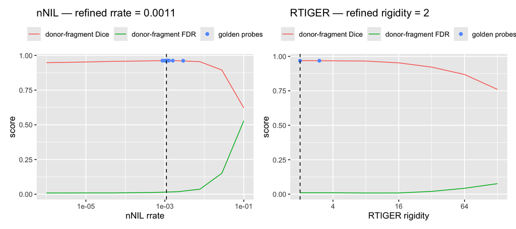

```r
calib_panel <- function(sweep, refine, star, xlab, xtrans) {
  ggplot(sweep, aes(value)) +
    geom_line(aes(y = donor_frag_dice, colour = "donor-fragment Dice")) +
    geom_line(aes(y = donor_frag_FDR, colour = "donor-fragment FDR")) +
    geom_point(data = refine, aes(value, objective, colour = "golden probes"), size = 1.6) +
    geom_vline(xintercept = star, linetype = "dashed") +
    xtrans +
    labs(x = xlab, y = "score", colour = NULL) +
    theme(legend.position = "top")
}
p_nnil <- calib_panel(nnil_sw, nnil_rf, par["rrate_star"], "nNIL rrate", scale_x_log10()) +
  ggtitle(sprintf("nNIL — refined rrate = %.2g", par["rrate_star"]))
p_rtig <- calib_panel(
  rtig_sw, rtig_rf, par["rigidity_star"], "RTIGER rigidity",
  scale_x_continuous(trans = "log2")
) +
  ggtitle(sprintf("RTIGER — refined rigidity = %d", as.integer(par["rigidity_star"])))
patchwork_ok <- requireNamespace("patchwork", quietly = TRUE)
if (patchwork_ok) {
  print(patchwork::wrap_plots(p_nnil, p_rtig))
} else {
  print(p_nnil)
  print(p_rtig)
}
```

```r
# The log-sweep curves (Dice peaks then over-fragments as FDR/breakpoints climb).
show <- function(s, pcol) {
  s[, .(
    value = signif(value, 3), donor_frag_dice = round(donor_frag_dice, 3),
    donor_frag_FDR = round(donor_frag_FDR, 3), donor_marker_recall = round(donor_marker_recall, 3),
    n_breakpoints, truth_bp, ks = round(ks_fragsize, 3)
  )]
}
cat("nNIL rrate log sweep:\n")
```

```
nNIL rrate log sweep:
```

```r
print(show(nnil_sw))
```

```
       value donor_frag_dice donor_frag_FDR donor_marker_recall n_breakpoints
       <num>           <num>          <num>               <num>         <int>
 1: 1.00e-06           0.948          0.009               0.995          4493
 2: 3.59e-06           0.950          0.009               0.995          4534
 3: 1.29e-05           0.953          0.009               0.995          4584
 4: 4.64e-05           0.957          0.009               0.996          4638
 5: 1.67e-04           0.959          0.011               0.996          4698
 6: 5.99e-04           0.962          0.013               0.996          4760
 7: 2.15e-03           0.962          0.018               0.996          4818
 8: 7.74e-03           0.955          0.036               0.996          4893
 9: 2.78e-02           0.895          0.151               0.995          5321
10: 1.00e-01           0.622          0.529               0.992          8351
    truth_bp    ks
       <int> <num>
 1:     5199 0.050
 2:     5199 0.046
 3:     5199 0.041
 4:     5199 0.037
 5:     5199 0.030
 6:     5199 0.025
 7:     5199 0.020
 8:     5199 0.013
 9:     5199 0.056
10:     5199 0.295
```

```r
cat("\nRTIGER rigidity log sweep (powers of 2, feasibility-capped):\n")
```

```
RTIGER rigidity log sweep (powers of 2, feasibility-capped):
```

```r
print(show(rtig_sw))
```

```
   value donor_frag_dice donor_frag_FDR donor_marker_recall n_breakpoints
   <num>           <num>          <num>               <num>         <int>
1:     2           0.969          0.010               0.996           961
2:     4           0.968          0.010               0.996           961
3:     8           0.966          0.009               0.996           953
4:    16           0.953          0.009               0.995           927
5:    32           0.922          0.020               0.994           872
6:    64           0.868          0.043               0.991           785
7:   128           0.760          0.076               0.980           630
   truth_bp    ks
      <int> <num>
1:     1038 0.025
2:     1038 0.029
3:     1038 0.036
4:     1038 0.059
5:     1038 0.111
6:     1038 0.166
7:     1038 0.280
```

# 3. Benchmark at the calibrated parameters (§2.5, §3.2)

Each caller run at its refined optimum on a held-out set, scored vs truth:

```r
bench[]
```

```
        caller       param marker_macro_dice donor_marker_dice
        <char>       <num>             <num>             <num>
1:   Skim-nNIL 0.001096669             0.995             0.998
2: Skim-RTIGER 2.000000000             0.996             0.998
   donor_marker_recall donor_frag_dice donor_frag_FDR ks_fragsize breakpoints
                 <num>           <num>          <num>       <num>       <int>
1:               0.996           0.963          0.015       0.022        4791
2:               0.997           0.964          0.013       0.021        4879
   breakpoints_truth
               <int>
1:              5199
2:              5199
```

# 4. Fragment-size fit (supplementary)

Donor-block size distributions vs the BC2S2 truth (the calibrated callers should track the truth’s fragment sizes; KS in the benchmark table).

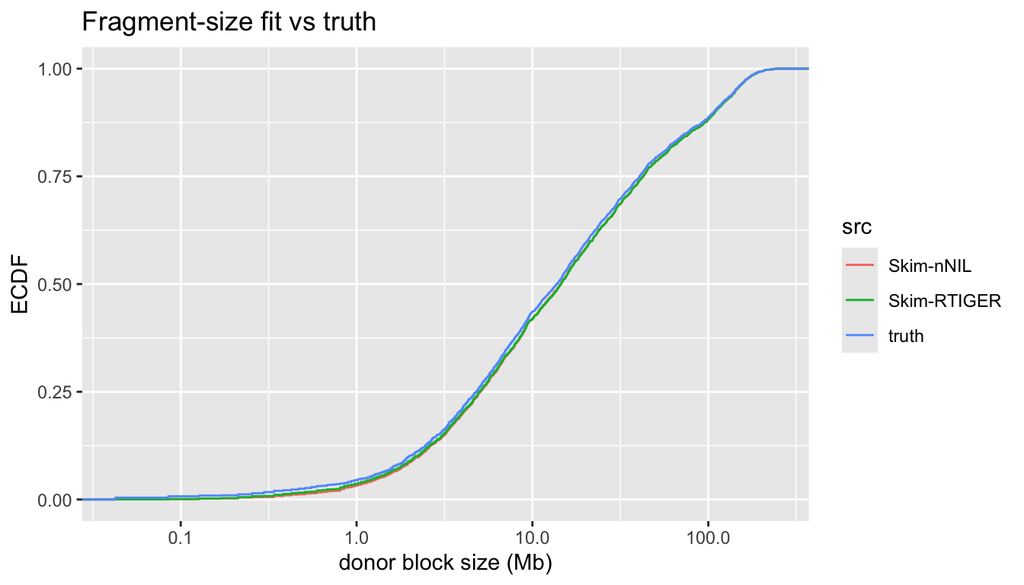

```r
ggplot(frag, aes(mb, colour = src)) +
  stat_ecdf() +
  scale_x_log10() +
  labs(x = "donor block size (Mb)", y = "ECDF", title = "Fragment-size fit vs truth")
```

# 5. Genotype-frequency vs the one-locus expectation (supplementary)

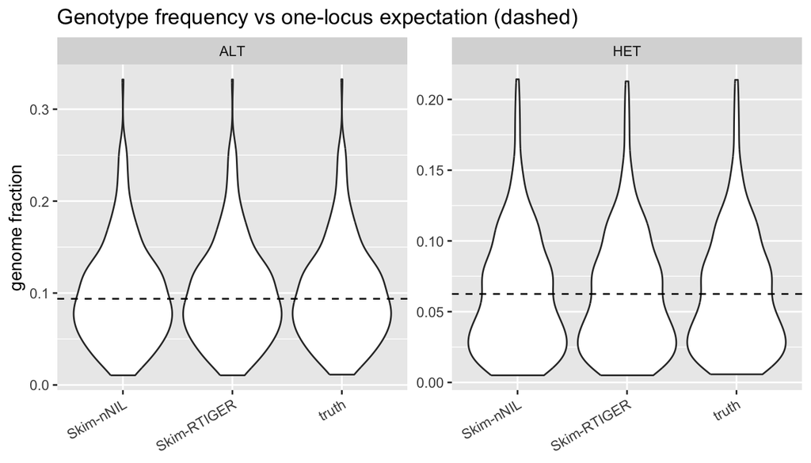

```r
ggplot(melt(geno[, .(src, HET, ALT)], id.vars = "src"), aes(src, value)) +
  geom_violin(scale = "width") +
  facet_wrap(~variable, scales = "free_y") +
  geom_hline(data = data.table(
    variable = c("HET", "ALT"), y = c(par["HET_expect"], par["ALT_expect"])
  ), aes(yintercept = y), linetype = "dashed") +
  labs(x = NULL, y = "genome fraction", title = "Genotype frequency vs one-locus expectation (dashed)") +
  theme(axis.text.x = element_text(angle = 30, hjust = 1))
```

# Next steps